# Occupancy Models

Andy

2/15/2022

# Exploring Mosquito and Dragonfly Occupancy

Now that we have a working temperature model, let’s play with occupancy models. First issue will be to determine detection probability for our two taxa of interest, dragonflies and mosquitoes.

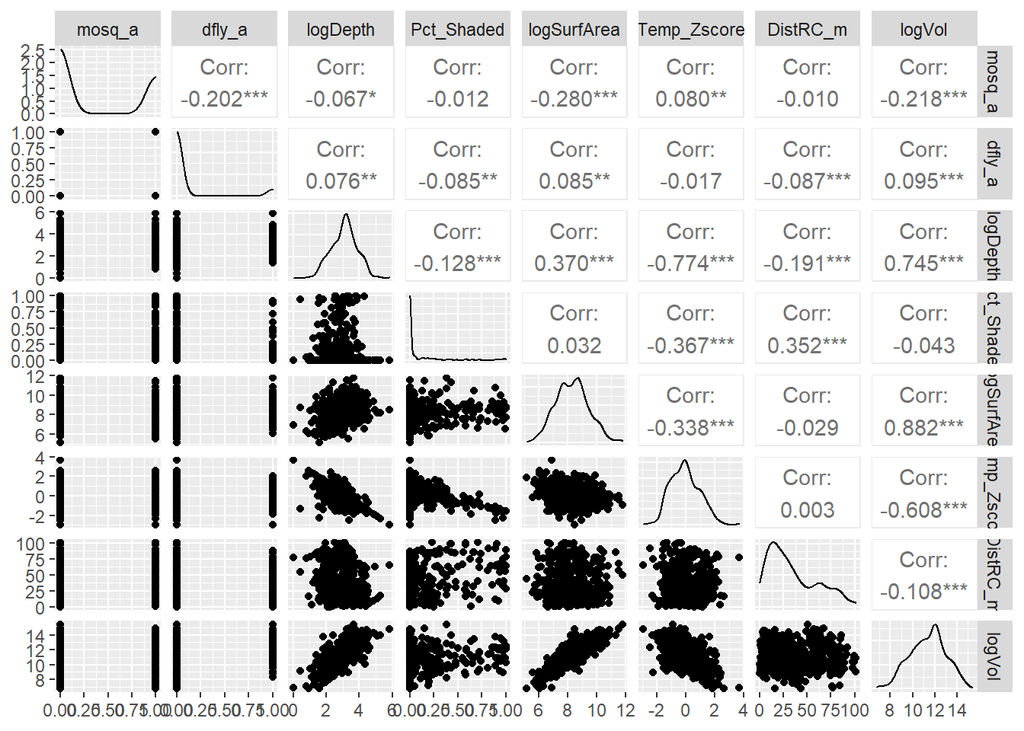

Mosquito occurrence correlates with pool volume, surface area, depth, and temperature. Meanwhile, dragonfly occurrence correlates with volume, surface area, depth, dist to river channel, and shading

Some of these variables overlap and/or are collinear, especially the dimensions. So, let’s narrow down our variables. Shading correlates with both distance to river channel and temperature, so let’s drop it. From the perspective of aerial colonizers, surface area is likely to be more important than depth or volume, so let’s drop both.

One caveat – surface area is also correlated with temperature here… hmm. Maybe that’s why the interaction term works.

So, that leaves us with mosquitoes as a function of surface area and temperature, and dragons as a function of surface area and distance to RC. Let’s Z-score standardize these as well.

# Model Selection

According to Josh, Julian date can be considered a detection covariate, because abundance of either spp. probably varies in time, and that could affect our ability to detect them.

For the full model, we’ll assume that Julian date determines detection, whereas occupancy itself is determined by temperature and surface area for mosquitoes, and distance to river channel and surface area for dragonflies. The probability of both occurring might have something to do with the variables that determine their occupancy separately.

```r
cand.models <- list()

# Full model
stateformulas <- c('~Temp_Z * SurfArea_Z', '~DistRC_Z + SurfArea_Z', '~Temp_Z * SurfArea_Z + DistRC_Z')
detformulas <- c('~JulianDate', '~JulianDate')

cand.models[[1]] <- occuMulti(stateformulas = stateformulas,
                  detformulas = detformulas,
             data = umf,
             se = TRUE)
```

Now let’s do some combo models where we drop terms.

```
##
## Model selection based on AICc:
##
##         K    AICc Delta_AICc AICcWt Cum.Wt       LL
## mod 23 12 2550.62       0.00   0.22   0.22 -1263.20
## mod 26 14 2550.66       0.04   0.22   0.44 -1261.18
## mod 53 16 2551.62       1.00   0.13   0.57 -1259.62
## mod 25 15 2552.44       1.82   0.09   0.66 -1261.05
## mod 22 13 2552.47       1.85   0.09   0.75 -1263.11
## mod 15 13 2552.60       1.98   0.08   0.83 -1263.17
## mod 51 14 2552.87       2.24   0.07   0.90 -1262.28
## mod 14 14 2554.44       3.81   0.03   0.93 -1263.07
## mod 54 15 2554.79       4.17   0.03   0.96 -1262.23
## mod 19 13 2557.97       7.35   0.01   0.97 -1265.86
## mod 46 17 2558.80       8.18   0.00   0.97 -1262.18
## mod 57 17 2558.91       8.29   0.00   0.97 -1262.24
## mod 37 14 2558.97       8.34   0.00   0.98 -1265.33
## mod 58 17 2559.09       8.47   0.00   0.98 -1262.33
## mod 45 17 2559.58       8.95   0.00   0.98 -1262.57
## mod 55 17 2559.58       8.95   0.00   0.99 -1262.57
## mod 18 14 2559.69       9.07   0.00   0.99 -1265.70
## mod 47 17 2559.71       9.08   0.00   0.99 -1262.64
## mod 42 19 2560.37       9.74   0.00   0.99 -1260.91
## mod 49 15 2560.61       9.99   0.00   0.99 -1265.13
## mod 7  15 2560.62      10.00   0.00   0.99 -1265.14
## mod 44 18 2560.63      10.01   0.00   1.00 -1262.07
## mod 43 18 2560.71      10.09   0.00   1.00 -1262.11
## mod 1  20 2561.65      11.03   0.00   1.00 -1260.53
## mod 6  16 2562.36      11.74   0.00   1.00 -1264.99
## mod 36 16 2562.36      11.74   0.00   1.00 -1264.99
## mod 60 15 2567.64      17.02   0.00   1.00 -1268.65
## mod 59 15 2567.77      17.15   0.00   1.00 -1268.72
## mod 10 15 2567.87      17.25   0.00   1.00 -1268.77
## mod 39 15 2567.87      17.25   0.00   1.00 -1268.77
## mod 21 12 2568.07      17.45   0.00   1.00 -1271.93
## mod 33 16 2568.62      17.99   0.00   1.00 -1268.12
## mod 56 16 2568.80      18.18   0.00   1.00 -1268.21
## mod 20 13 2569.13      18.51   0.00   1.00 -1271.44
## mod 9  13 2569.74      19.12   0.00   1.00 -1271.74
## mod 32 13 2569.74      19.12   0.00   1.00 -1271.74
```

[output cut: 9 more lines]

```
## mod 34 14 2572.43      21.81   0.00   1.00 -1272.07
## mod 52 16 2573.26      22.64   0.00   1.00 -1270.44
## mod 29 15 2574.31      23.69   0.00   1.00 -1271.99
## mod 48 15 2574.31      23.69   0.00   1.00 -1271.99
## mod 16 13 2617.83      67.21   0.00   1.00 -1295.79
## mod 35 14 2618.22      67.60   0.00   1.00 -1294.96
## mod 27 14 2619.62      69.00   0.00   1.00 -1295.66
## mod 4  15 2620.10      69.48   0.00   1.00 -1294.88
## mod 17 12 2626.80      76.18   0.00   1.00 -1301.29
## mod 5  13 2628.56      77.94   0.00   1.00 -1301.15
## mod 28 13 2628.56      77.94   0.00   1.00 -1301.15
## mod 24 12 2628.85      78.23   0.00   1.00 -1302.31
## mod 12 13 2629.05      78.42   0.00   1.00 -1301.39
## mod 41 13 2629.05      78.42   0.00   1.00 -1301.39
## mod 13 11 2637.92      87.30   0.00   1.00 -1307.87
```

The top performing models:

```r
## Top performing models:
summary(cand.models[[23]]) # Only includes surface area for dragonflies, which has a positive effect; NaNs produced though
```

```
##
## Call:
## occuMulti(detformulas = detformulas, stateformulas = stateformulas,
##     data = umf, se = TRUE)
##
## Occupancy (logit-scale):
##                       Estimate     SE       z  P(>|z|)
## [sp1] (Intercept)        14.61 330.43  0.0442 9.65e-01
## [sp2] (Intercept)        16.33 330.43  0.0494 9.61e-01
## [sp2] SurfArea_Z          4.97   1.19  4.1618 3.16e-05
## [sp1:sp2] (Intercept)   -15.50 330.43 -0.0469 9.63e-01
```

```
## Detection (logit-scale):
##                     Estimate    SE     z  P(>|z|)
## [sp1] (Intercept)       3.17 0.660  4.80 1.56e-06
## [sp1] JulianDate159    17.77   NaN   NaN      NaN
## [sp1] JulianDate172    -2.06 0.656 -3.13 1.72e-03
## [sp1] JulianDate223    -3.92 0.659 -5.95 2.73e-09
## [sp2] (Intercept)      -4.22 0.507 -8.33 7.80e-17
## [sp2] JulianDate159     1.02 0.882  1.16 2.47e-01
## [sp2] JulianDate172     1.67 0.540  3.10 1.94e-03
## [sp2] JulianDate223     3.53 0.520  6.79 1.09e-11
##
## AIC: 2550.401
## Number of sites: 1430
## optim convergence code: 0
## optim iterations: 100
## Bootstrap iterations: 0
```

```r
summary(cand.models[[26]]) # Includes temperature for mosquitoes (-, n.s.), surface area for dragonflies (+), temperature for both (+)
```

```
##
## Call:
## occuMulti(detformulas = detformulas, stateformulas = stateformulas,
##     data = umf, se = TRUE)
##
## Occupancy (logit-scale):
##                       Estimate      SE       z  P(>|z|)
## [sp1] (Intercept)       15.393 565.669  0.0272 0.978291
## [sp1] Temp_Z            -0.173   0.136 -1.2743 0.202566
## [sp2] (Intercept)       17.153 565.669  0.0303 0.975809
## [sp2] SurfArea_Z         5.130   1.303  3.9386 0.000082
## [sp1:sp2] (Intercept)  -16.254 565.669 -0.0287 0.977077
## [sp1:sp2] Temp_Z         0.415   0.207  2.0086 0.044584
##
## Detection (logit-scale):
##                     Estimate       SE       z  P(>|z|)
## [sp1] (Intercept)       3.11    0.654  4.7591 1.94e-06
## [sp1] JulianDate159    13.65 1211.021  0.0113 9.91e-01
## [sp1] JulianDate172    -1.99    0.649 -3.0655 2.17e-03
## [sp1] JulianDate223    -3.87    0.652 -5.9268 3.09e-09
## [sp2] (Intercept)      -4.22    0.507 -8.3205 8.76e-17
## [sp2] JulianDate159     1.01    0.882  1.1459 2.52e-01
## [sp2] JulianDate172     1.67    0.540  3.0896 2.00e-03
## [sp2] JulianDate223     3.52    0.520  6.7653 1.33e-11
##
## AIC: 2550.364
## Number of sites: 1430
## optim convergence code: 0
## optim iterations: 110
## Bootstrap iterations: 0
```

```r
summary(cand.models[[53]]) # Includes temperature for mosquitoes (-, n.s.), distance to river channel (-, n.s.) and surface area (+) for dragonflies, and temperature (+) and distance to river channel (-, n.s.) for both
```

```
##
## Call:
## occuMulti(detformulas = detformulas, stateformulas = stateformulas,
##     data = umf, se = TRUE)
##
## Occupancy (logit-scale):
##                       Estimate       SE       z  P(>|z|)
## [sp1] (Intercept)       31.717 1488.584  0.0213 9.83e-01
## [sp1] Temp_Z            -0.195    0.138 -1.4165 1.57e-01
## [sp2] (Intercept)       33.486 1488.584  0.0225 9.82e-01
## [sp2] DistRC_Z          -0.111    0.112 -0.9825 3.26e-01
## [sp2] SurfArea_Z         5.139    1.129  4.5508 5.35e-06
## [sp1:sp2] (Intercept)  -32.579 1488.584 -0.0219 9.83e-01
## [sp1:sp2] Temp_Z         0.488    0.213  2.2927 2.19e-02
## [sp1:sp2] DistRC_Z      -0.251    0.152 -1.6439 1.00e-01
##
## Detection (logit-scale):
##                     Estimate      SE       z  P(>|z|)
## [sp1] (Intercept)       3.05   0.648  4.7127 2.44e-06
## [sp1] JulianDate159    12.33 692.175  0.0178 9.86e-01
## [sp1] JulianDate172    -1.94   0.641 -3.0312 2.44e-03
## [sp1] JulianDate223    -3.82   0.645 -5.9151 3.32e-09
## [sp2] (Intercept)      -4.23   0.506 -8.3470 7.00e-17
## [sp2] JulianDate159     1.01   0.881  1.1478 2.51e-01
## [sp2] JulianDate172     1.68   0.540  3.1074 1.89e-03
## [sp2] JulianDate223     3.52   0.520  6.7714 1.28e-11
##
## AIC: 2551.234
## Number of sites: 1430
## optim convergence code: 0
## optim iterations: 125
## Bootstrap iterations: 0
```

```r
summary(cand.models[[25]]) # This one looks a little funky and has some NaNs for the intercept estimates
```

```
##
## Call:
## occuMulti(detformulas = detformulas, stateformulas = stateformulas,
##     data = umf, se = TRUE)
```

```
## Occupancy (logit-scale):
##                       Estimate    SE      z  P(>|z|)
## [sp1] (Intercept)       48.324   NaN    NaN      NaN
## [sp1] Temp_Z            -0.171 0.136 -1.257 2.09e-01
## [sp2] (Intercept)       50.070   NaN    NaN      NaN
## [sp2] DistRC_Z          -0.056 0.110 -0.509 6.11e-01
## [sp2] SurfArea_Z         5.101 1.273  4.006 6.19e-05
## [sp1:sp2] (Intercept)  -49.184   NaN    NaN      NaN
## [sp1:sp2] Temp_Z         0.418 0.207  2.023 4.31e-02
##
## Detection (logit-scale):
##                     Estimate       SE       z  P(>|z|)
## [sp1] (Intercept)       3.09    0.652  4.7411 2.13e-06
## [sp1] JulianDate159    13.81 1111.110  0.0124 9.90e-01
## [sp1] JulianDate172    -1.97    0.647 -3.0533 2.26e-03
## [sp1] JulianDate223    -3.85    0.651 -5.9179 3.26e-09
## [sp2] (Intercept)      -4.22    0.507 -8.3218 8.66e-17
## [sp2] JulianDate159     1.01    0.882  1.1461 2.52e-01
## [sp2] JulianDate172     1.67    0.540  3.0924 1.99e-03
## [sp2] JulianDate223     3.52    0.520  6.7678 1.31e-11
##
## AIC: 2552.104
## Number of sites: 1430
## optim convergence code: 0
## optim iterations: 118
## Bootstrap iterations: 0
```

```r
summary(cand.models[[22]]) # No predicted for mosquitoes or the intercept, distance to river channel (-, n.s.) and surface area (+) for dragonflies
```

```
##
## Call:
## occuMulti(detformulas = detformulas, stateformulas = stateformulas,
##     data = umf, se = TRUE)
##
## Occupancy (logit-scale):
##                       Estimate      SE       z  P(>|z|)
## [sp1] (Intercept)      77.3946 807.271  0.0959 9.24e-01
## [sp2] (Intercept)      79.0977 807.271  0.0980 9.22e-01
## [sp2] DistRC_Z         -0.0479   0.111 -0.4324 6.65e-01
## [sp2] SurfArea_Z        4.9376   1.176  4.1985 2.69e-05
## [sp1:sp2] (Intercept) -78.2833 807.271 -0.0970 9.23e-01
##
## Detection (logit-scale):
##                     Estimate      SE       z  P(>|z|)
## [sp1] (Intercept)       3.16   0.659  4.7914 1.66e-06
## [sp1] JulianDate159     9.77 199.072  0.0491 9.61e-01
## [sp1] JulianDate172    -2.05   0.654 -3.1266 1.77e-03
## [sp1] JulianDate223    -3.91   0.658 -5.9416 2.82e-09
## [sp2] (Intercept)      -4.22   0.507 -8.3335 7.85e-17
## [sp2] JulianDate159     1.02   0.882  1.1572 2.47e-01
## [sp2] JulianDate172     1.67   0.540  3.1009 1.93e-03
## [sp2] JulianDate223     3.53   0.520  6.7971 1.07e-11
##
## AIC: 2552.215
## Number of sites: 1430
## optim convergence code: 0
## optim iterations: 105
## Bootstrap iterations: 0
```

```r
summary(cand.models[[15]]) # Includes temperature (+, n.s.) for mosquitoes, surface area (+) for dragons, nothing for both
```

```
##
## Call:
## occuMulti(detformulas = detformulas, stateformulas = stateformulas,
##     data = umf, se = TRUE)
##
## Occupancy (logit-scale):
##                       Estimate      SE       z  P(>|z|)
## [sp1] (Intercept)      14.8357 370.729  0.0400 9.68e-01
## [sp1] Temp_Z            0.0204   0.085  0.2398 8.10e-01
## [sp2] (Intercept)      16.5200 370.729  0.0446 9.64e-01
## [sp2] SurfArea_Z        4.8919   1.237  3.9559 7.62e-05
## [sp1:sp2] (Intercept) -15.7208 370.729 -0.0424 9.66e-01
##
## Detection (logit-scale):
##                     Estimate       SE        z  P(>|z|)
## [sp1] (Intercept)       3.17    0.660  4.80150 1.57e-06
## [sp1] JulianDate159    18.78 4339.256  0.00433 9.97e-01
## [sp1] JulianDate172    -2.06    0.656 -3.13942 1.69e-03
## [sp1] JulianDate223    -3.92    0.659 -5.94811 2.71e-09
## [sp2] (Intercept)      -4.22    0.507 -8.32986 8.09e-17
## [sp2] JulianDate159     1.02    0.882  1.15669 2.47e-01
## [sp2] JulianDate172     1.67    0.540  3.09923 1.94e-03
## [sp2] JulianDate223     3.53    0.520  6.79538 1.08e-11
##
## AIC: 2552.344
## Number of sites: 1430
## optim convergence code: 0
## optim iterations: 104
## Bootstrap iterations: 0
```

The above models are a bit of a mish-mash. Some include temperature for mosquitoes, but it’s usually n.s. and sometimes negative, which is different from previous models. Surface area shows up a lot for dragonflies, and distance to river channel (which is usually n.s.).

# Occupancy Probabilities

For now, we will move forward with model 26, because the other top model has NaNs. Need to ask about what to do with these.

```r
# What's mean occupancy of all three states?; aka marginal occupancy probabilities
margin.sp1 <- predict(cand.models[[26]], 'state', species = 1)
```

```
## Bootstrapping confidence intervals with 100 samples
```

```r
mean(margin.sp1[,1]) # 53.6% chance of mosquito occupancy
```

```
## [1] 0.535541
```

```r
margin.sp2 <- predict(cand.models[[26]], 'state', species = 2)
```

```
## Bootstrapping confidence intervals with 100 samples
```

```r
mean(margin.sp2[,1]) # 65.7% chance of dragonfly occupancy
```

```
## [1] 0.656769
```

```r
margin.sp1sp2 <- predict(cand.models[[26]], 'state', species = c(1, 2))
```

```
## Bootstrapping confidence intervals with 100 samples
```

```r
mean(margin.sp1sp2[,1]) # 19.2% chance that both occur together
```

```
## [1] 0.1923102
```

```r
# Impact of dragons on mosquitoes; aka conditional occupancy probabilities
cond1 <- predict(cand.models[[26]], 'state', species = 1, cond = 2) # Probability of mosquitoes given dragonfly
```

```
## Bootstrapping confidence intervals with 100 samples
```

```r
mean(cond1[,1]) # Only a 29.6% chance of mosquitoes given dragonflies
```

```
## [1] 0.2959321
```

```r
cond2 <- predict(cand.models[[26]], 'state', species = 1, cond = -2) # Probability of mosquitoes given no dragonfly
```

```
## Bootstrapping confidence intervals with 100 samples
```

```r
mean(cond2[,1]) # Nearly 100% chance of mosquitoes given no dragonfly... which seems impossible, no?
```

```
## [1] 0.9999998
```

```r
odds.ratio1 <- cond1/cond2
log(odds.ratio1) # Log odds ratio suggests negative effect of dragons on mosquito occupancy
```

[output not shown]

[output cut: 1416 more lines]

```r
# So if this model is correct, dragons go wherever in the landscape regardless of temperature but seem to occur more often in bigger pools, while mosquitoes seem to occur slightly more often in warmer pools. The presence of dragons reduces the likelihood of mosquitoes being present, but this effect is weaker in warmer pools.
```

# Figures

```r
TempZ.vec <- seq(-2.9, 4.0, by = 0.1) # Vector of possible temperature z-scores
SurfArea.vec <- rep(0, length(TempZ.vec)) # Surface area held constant
mosq_plot.df <- as.data.frame(cbind(TempZ.vec, SurfArea.vec))
names(mosq_plot.df) <- c("Temp_Z", "SurfArea_Z")
mosq.predict <- predict(cand.models[[26]], mosq_plot.df, type = 'state', species = 1)
```

```
## Bootstrapping confidence intervals with 100 samples
```

```r
mosq.predict$Temp_C <- mosq_plot.df$Temp_Z * sd(occupancy.df$Temp_Predicted_C) + mean(occupancy.df$Temp_Predicted_C)


SurfArea.vec <- seq(-0.6, 9.8, by = 0.1) # Vector of possible surface area z-scores
TempZ.vec <- rep(0, length(SurfArea.vec)) # Temperature held constant
drgn_plot.df <- as.data.frame(cbind(TempZ.vec, SurfArea.vec))
names(drgn_plot.df) <- c("Temp_Z", "SurfArea_Z")
drgn.predict <- predict(cand.models[[26]], drgn_plot.df, type = 'state', species = 2)
```

```
## Bootstrapping confidence intervals with 100 samples
```

```r
drgn.predict$SurfArea_cm2 <- log(drgn_plot.df$SurfArea_Z * sd(occupancy.df$SurfArea_cm2) + mean(occupancy.df$SurfArea_cm2))


TempZ.vec <- seq(-2.9, 4.0, by = 0.1) # Vector of possible temperature z-scores
SurfArea.vec <- rep(0, length(TempZ.vec)) # Surface area held constant
both_plot.df <- as.data.frame(cbind(TempZ.vec, SurfArea.vec))
names(both_plot.df) <- c("Temp_Z", "SurfArea_Z")
both.predict <- predict(cand.models[[26]], both_plot.df, type = 'state', species = c(1,2))
```

```
## Bootstrapping confidence intervals with 100 samples
```

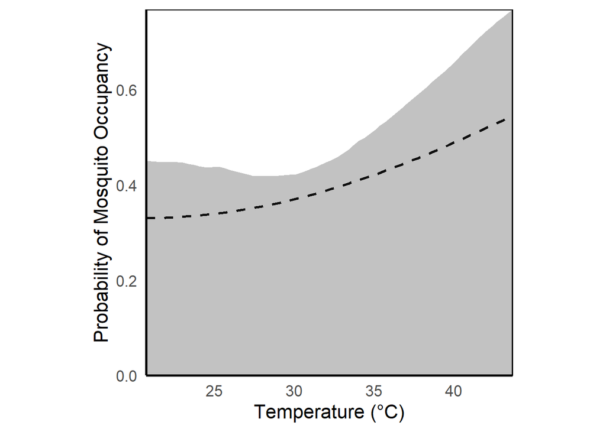

```r
both.predict$Temp_C <- both_plot.df$Temp_Z * sd(occupancy.df$Temp_Predicted_C) + mean(occupancy.df$Temp_Predicted_C)

ggplot( data = mosq.predict, aes( x = Temp_C, y = Predicted ) ) +
  geom_line( size = 1, linetype = 2 ) +
  geom_ribbon( aes( ymin = lower, ymax = upper ), alpha = 0.3) +
  xlab( "Temperature (°C)" ) +
  ylab( "Probability of Mosquito Occupancy" ) +
  theme_classic( base_size = 16, base_line_size = 1 ) +
  scale_y_continuous(expand = c(0,0)) +
  scale_x_continuous(expand = c(0,0)) +
  theme( legend.position = "none",
         axis.ticks = element_blank(),
         panel.border = element_rect( color = "black", fill = NA, size = 0.75 ),
         aspect.ratio = 1 )
```

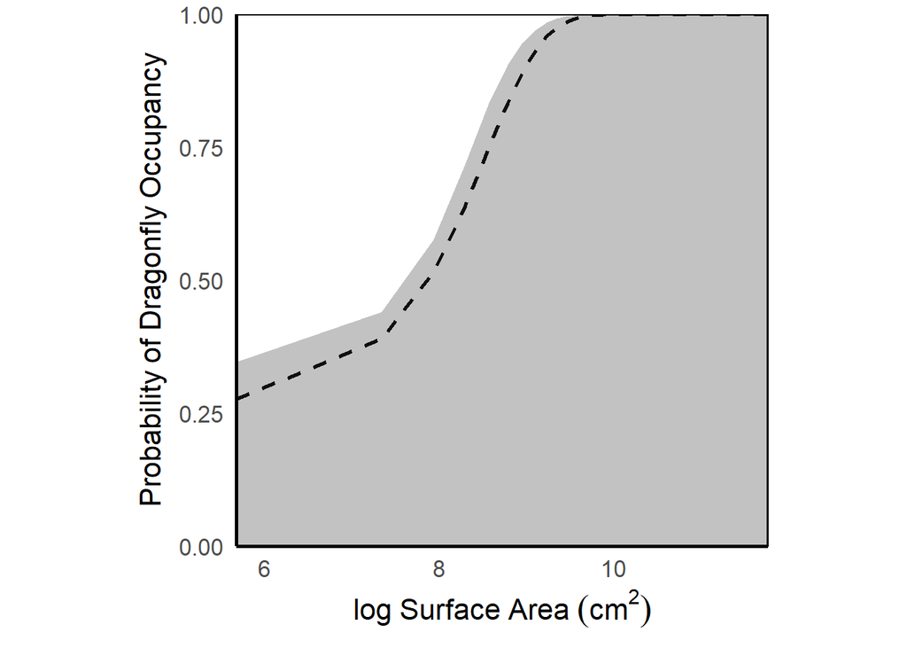

```r
ggplot( data = drgn.predict, aes( x = SurfArea_cm2, y = Predicted ) ) +
  geom_line( size = 1, linetype = 2 ) +
  geom_ribbon( aes( ymin = lower, ymax = upper ), alpha = 0.3) +
  labs(y = expression(Probability~of~Dragonfly~Occupancy), x = expression(log~Surface~Area~(cm^2))) +
  theme_classic( base_size = 16, base_line_size = 1 ) +
  scale_y_continuous(expand = c(0,0)) +
  scale_x_continuous(expand = c(0,0)) +
  theme( legend.position = "none",
         axis.ticks = element_blank(),
         panel.border = element_rect( color = "black", fill = NA, size = 0.75 ),
         aspect.ratio = 1 )
```

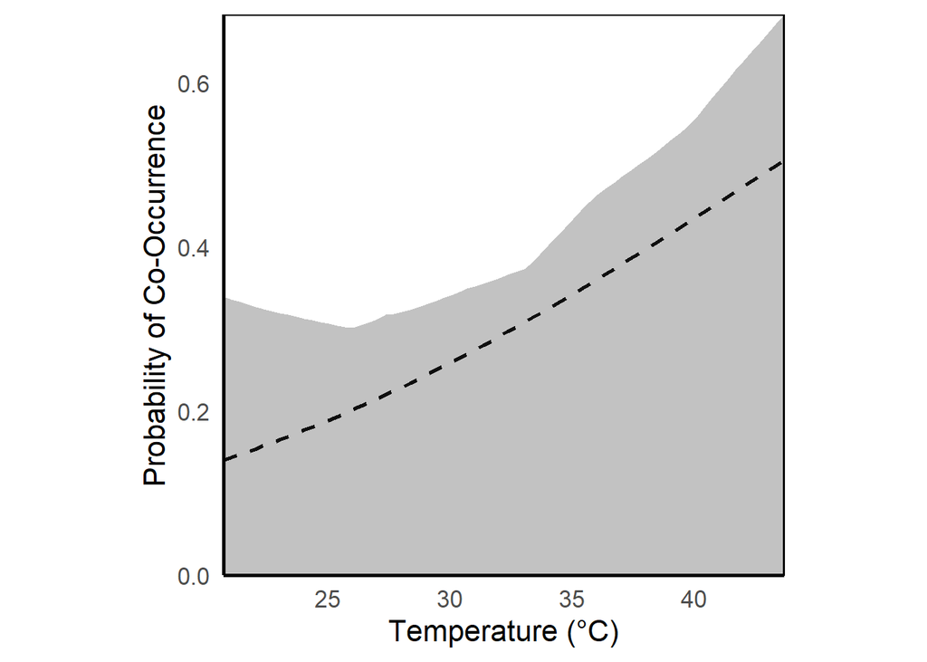

```r
ggplot( data = both.predict, aes( x = Temp_C, y = Predicted ) ) +
  geom_line( size = 1, linetype = 2 ) +
  geom_ribbon( aes( ymin = lower, ymax = upper ), alpha = 0.3) +
  xlab( "Temperature (°C)" ) +
  ylab( "Probability of Co-Occurrence" ) +
  theme_classic( base_size = 16, base_line_size = 1 ) +
  scale_y_continuous(expand = c(0,0)) +
  scale_x_continuous(expand = c(0,0)) +
  theme( legend.position = "none",
         axis.ticks = element_blank(),
         panel.border = element_rect( color = "black", fill = NA, size = 0.75 ),
         aspect.ratio = 1 )
```